# Laterally confined growth for stem cell engineering: Looking at the trascriptome

Saradha Venkatachapathy

# Introduction

In the paper, we present a novel assay for reprogramming fibroblasts into iPSC-like cells in the absence of exogeous factors. Briefly, mouse embryonic fibroblasts (NIH3T3) were cultured such that their growth was confined on rectangular islands. After 10 days of such latterally confined growth, we observed that they acquired stem cell characteristics. We perfored RNASeq and obtained the transciption profile of cells after 3 hours(S1), 3 days(S2), 6 days(S3) and 10 days(S4) of laterally confined growth on micropatterns. Here we present proof that latterally confined growth induces nuclear reprogramming.

# Characterizing the expression of candidate genes

We read in the gene expression counts and check the expression of candidate genes. Note, the candidate gene and the important gene lists were complied from Literature Review.

Labels: Mesenchymal (Me), Embryonic Stem cell(ES) and induced Pluripotent Stem Cells(iPSC).

```r
rnaseq_mapped_genes<-read.csv("./allcombined_gene_level_expression_mapped_to_gene_name.csv")
rnaseq_mapped_genes<-rnaseq_mapped_genes[,-1]
rnaseq_mapped_genes[,79]<-apply(rnaseq_mapped_genes[,75:78],1,mean)
rnaseq_mapped_genes[,80]<-apply(rnaseq_mapped_genes[,75:78],1,sd)
colnames(rnaseq_mapped_genes)[79:80]<-c("Pop_Mean","Pop_Std_Dev")

rnaseq_mapped_genes[,81]<-(rnaseq_mapped_genes[,75]-rnaseq_mapped_genes[,79])/rnaseq_mapped_genes[,80]
rnaseq_mapped_genes[,82]<-(rnaseq_mapped_genes[,76]-rnaseq_mapped_genes[,79])/rnaseq_mapped_genes[,80]
rnaseq_mapped_genes[,83]<-(rnaseq_mapped_genes[,77]-rnaseq_mapped_genes[,79])/rnaseq_mapped_genes[,80]
rnaseq_mapped_genes[,84]<-(rnaseq_mapped_genes[,78]-rnaseq_mapped_genes[,79])/rnaseq_mapped_genes[,80]
colnames(rnaseq_mapped_genes)[81:84]<-c("D0_zscore","D3_zscore","D6_zscore","D10_zscore")

# Fold changes

rnaseq_mapped_genes[,85]<-rnaseq_mapped_genes[,76]/rnaseq_mapped_genes[,75]#D3/D0
rnaseq_mapped_genes[,86]<-rnaseq_mapped_genes[,77]/rnaseq_mapped_genes[,75]#D6/D0
rnaseq_mapped_genes[,87]<-rnaseq_mapped_genes[,78]/rnaseq_mapped_genes[,75]#D10/D0
rnaseq_mapped_genes[,88]<-rnaseq_mapped_genes[,77]/rnaseq_mapped_genes[,76]#D6/D3
rnaseq_mapped_genes[,89]<-rnaseq_mapped_genes[,78]/rnaseq_mapped_genes[,76]#D10/D3
rnaseq_mapped_genes[,90]<-rnaseq_mapped_genes[,78]/rnaseq_mapped_genes[,77]#D10/D6

#read int the genelists
candidate_genes <- read.csv("~/Desktop/bibhas/candidate_genes.csv")
candidate_genes[,1] <- as.character(candidate_genes[,1])
Me<-subset(rnaseq_mapped_genes,rnaseq_mapped_genes[,1] %in% candidate_genes[,1])
candidate_genes[,2] <- as.character(candidate_genes[,2])
ES<-subset(rnaseq_mapped_genes,rnaseq_mapped_genes[,1] %in% candidate_genes[,2])
candidate_genes[,3] <- as.character(candidate_genes[,3])
iPSC<-subset(rnaseq_mapped_genes,rnaseq_mapped_genes[,1] %in% candidate_genes[,3])
```

First we see a decrease in the expression of Mesenchymal genes.

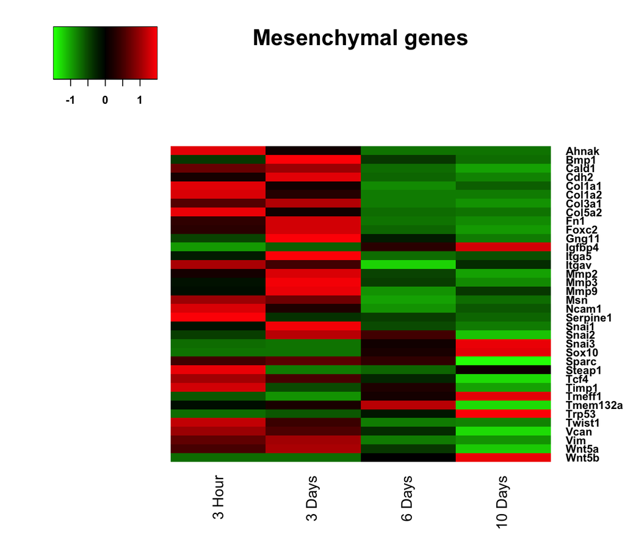

```r
library("gplots")
par(font.axis=2,font.lab=2,mfrow=c(1,3))
x<-heatmap.2(as.matrix(Me[,75:78]), col=greenred(75),
             scale="row",key=T, symkey=T, Rowv=F,Colv=FALSE,cexRow=0.9,
             trace='none',dendrogram="none",cexCol=1.2,srtCol =90,key.title=" ",key.xlab="",cex.axis=0.7,
             ylab = "",labRow = Me[,1],labCol=c("3 Hour","3 Days","6 Days","10 Days"),density.info="none",
             main="Mesenchymal genes")
```

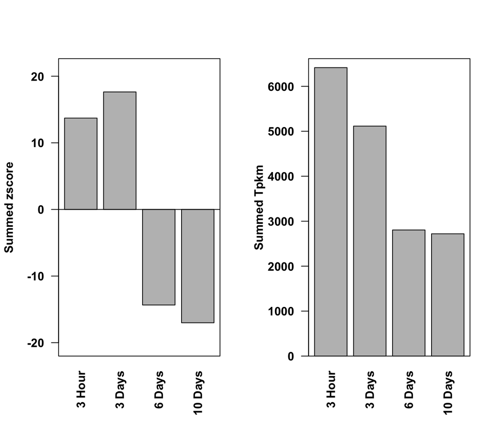

```r
me_zscore<-as.data.frame(x$carpet)
par(font.axis=2,font.lab=2,mfrow=c(1,2))
t<-rowSums(me_zscore)
t_up<-max(t)+5
t_dw<-min(t)-5
barplot(t,las=2,ylab="Summed zscore",names =c("3 Hour","3 Days","6 Days","10 Days"),ylim=c(t_dw,t_up))
box()
abline(h=0)
x<-colSums(Me[,75:78])
x_up<-max(x)+200
barplot(x,las=2,ylab="Summed Tpkm",names =c("3 Hour","3 Days","6 Days","10 Days"),ylim=c(0,x_up))
box()
```

Then we see an increase in the expression of Embryonic Stem cell (ES) genes.

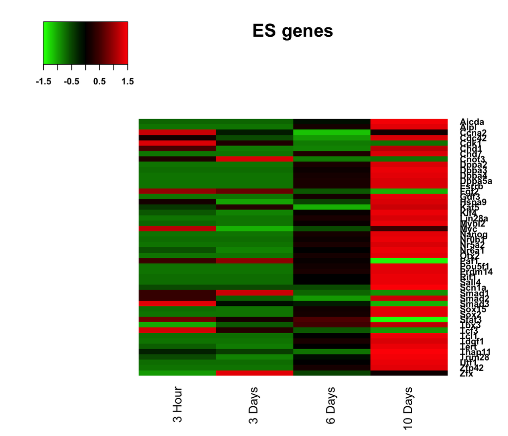

```r
par(font.axis=2,font.lab=2,mfrow=c(1,1))
x<-heatmap.2(as.matrix(ES[,75:78]), col=greenred(75),
             scale="row",key=T, symkey=T, Rowv=F,Colv=FALSE,cexRow=0.9,
             trace='none',dendrogram="none",cexCol=1.2,srtCol =90,key.title=" ",key.xlab="",cex.axis=0.7,
             ylab = "",labRow = ES[,1],labCol=c("3 Hour","3 Days","6 Days","10 Days"),density.info="none",
             main="ES genes")
```

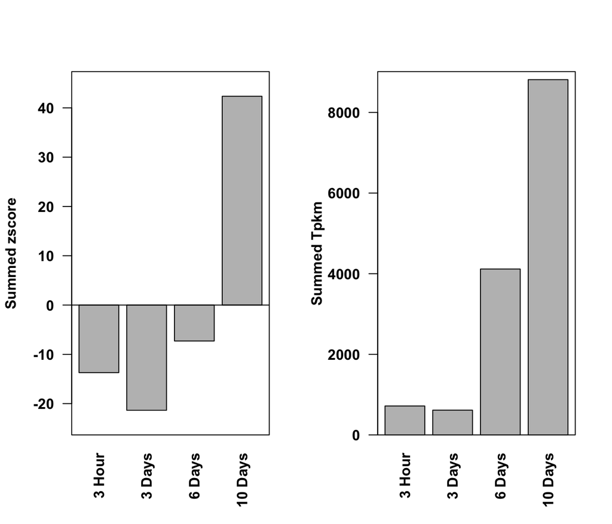

```r
es_zscore<-as.data.frame(x$carpet)
par(font.axis=2,font.lab=2,mfrow=c(1,2))
t<-rowSums(es_zscore)
t_up<-max(t)+5
t_dw<-min(t)-5
barplot(t,las=2,ylab="Summed zscore",names =c("3 Hour","3 Days","6 Days","10 Days"),ylim=c(t_dw,t_up))
box()
abline(h=0)
par(font.axis=2,font.lab=2)
x<-colSums(ES[,75:78])
x_up<-max(x)+200
barplot(x,las=2,ylab="Summed Tpkm",names =c("3 Hour","3 Days","6 Days","10 Days"),ylim=c(0,x_up))
box()
```

Also we see an increase in the expression of iPSC genes.

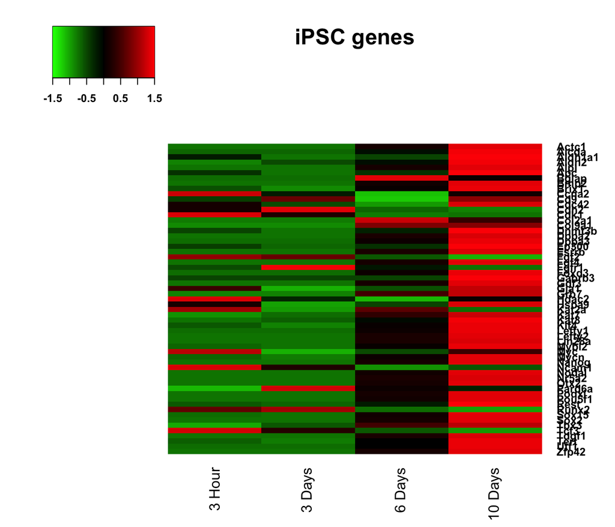

```r
par(font.axis=2,font.lab=2,mfrow=c(1,1))
x<-heatmap.2(as.matrix(iPSC[,75:78]), col=greenred(75),
             scale="row",key=T, symkey=T, Rowv=F,Colv=FALSE,cexRow=0.9,
             trace='none',dendrogram="none",cexCol=1.2,srtCol =90,key.title=" ",key.xlab="",cex.axis=0.7,
             ylab = "",labRow = iPSC[,1],labCol=c("3 Hour","3 Days","6 Days","10 Days"),density.info="none",
             main="iPSC genes")
```

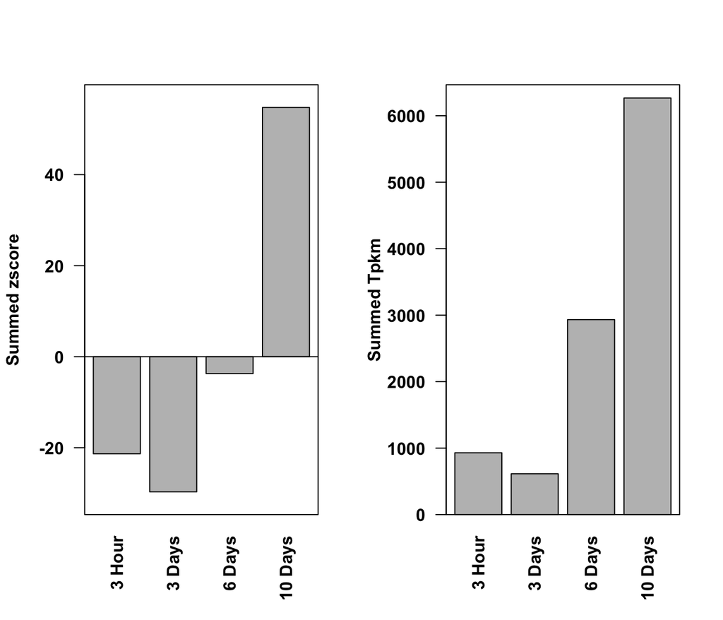

```r
iPSC_zscore<-as.data.frame(x$carpet)
par(font.axis=2,font.lab=2,mfrow=c(1,2))
t<-rowSums(iPSC_zscore, na.rm = T)
t_up<-max(t)+5
t_dw<-min(t)-5
barplot(t,las=2,ylab="Summed zscore",names =c("3 Hour","3 Days","6 Days","10 Days"),ylim=c(t_dw,t_up))
box()
abline(h=0)
x<-colSums(iPSC[,75:78])
x_up<-max(x)+200
barplot(x,las=2,ylab="Summed Tpkm",names =c("3 Hour","3 Days","6 Days","10 Days"),ylim=c(0,x_up))
box()
```

Overall we find an increase in the stem cell marker genes and a decrease in the mesenchymal genes

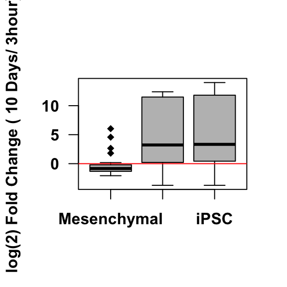

```r
# fold change
par(font.axis=2,font.lab=2)
Me[,87]<-Me[,78]/Me[,75]
ES[,87]<-ES[,78]/ES[,75]
iPSC[,87]<-iPSC[,78]/iPSC[,75]
boxplot(log(Me[,87],base=2),log(ES[,87],base=2),log(iPSC[,87],base=2),na.rm=T, las=1, col="gray",pch=18, names=c("Mesenchymal","ES","iPSC"),
        ylab="log(2) Fold Change ( 10 Days/ 3hour)",lty=1)
abline(h=0, lwd=1,col="red")
```

We specifically see a monotonous decay in the expression of mesenchymal genes whereas we see a biphasic expression of stem cell genes

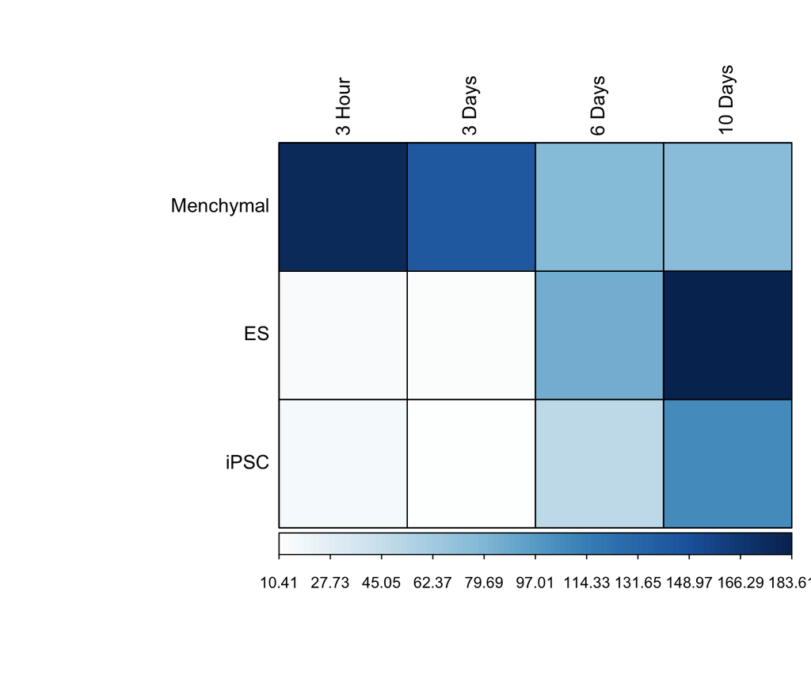

```r
temp<-as.matrix(rbind(colMeans(Me[,75:78]),colMeans(ES[,75:78]),colMeans(iPSC[,75:78])))
colnames(temp)<-c("3 Hour","3 Days","6 Days","10 Days")
rownames(temp)<-c("Menchymal","ES","iPSC")
library("corrplot")
corrplot(as.matrix(temp),is.corr=F, tl.col="black",cl.pos="b", cl.ratio=0.3,method="color",addgrid.col="black")
```

Lastly, plot the bar plot of some important genes. Error bars are 95% CI.

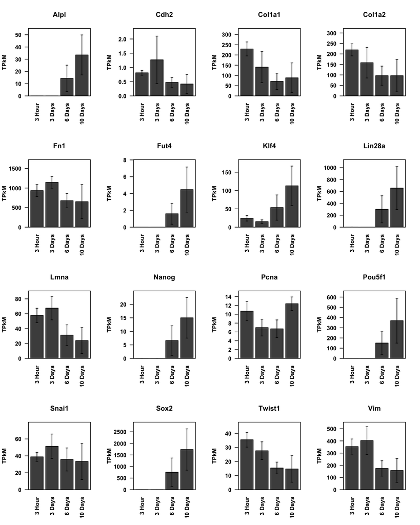

```r
imp<-c("Cdh2","Col1a1","Fn1","Snai1","Vim","Twist1","Col1a2","Alpl","Nanog","Pou5f1","Lin28a","Sox2","Fut4","Klf4","Lmna","Pcna")
imp_genes<-subset(rnaseq_mapped_genes,rnaseq_mapped_genes[,1] %in% imp)
error.bar <- function(x, y, upper, lower=upper, length=0.02,...){
  if(length(x) != length(y) | length(y) !=length(lower) | length(lower) != length(upper))
    stop("vectors must be same length")
  arrows(x,y+upper, x, y-lower, angle=90, code=3, length=length, ...)
}
par(font.axis=2,font.lab=2,mfrow=c(4,4))

for( i in 1:nrow(imp_genes)){
  y.means<-as.vector(imp_genes[i,c(75:78)])
  a<-apply(imp_genes[i,c(63,67,71)],1,sd)
  b<-apply(imp_genes[i,c(64,68,72)],1,sd)
  c<-apply(imp_genes[i,c(65,69,73)],1,sd)
  d<-apply(imp_genes[i,c(66,70,74)],1,sd)
  y.sd<-(as.vector(c(a,b,c,d)))
  ylimitup<-max(y.means)+1.5*max(y.sd)
  barx <- barplot(as.matrix(y.means), names=c("3 Hour","3 Days","6 Days","10 Days"),main=imp_genes[i,1],ylim=c(0,ylimitup),las=2,ylab="TPkM",cex.axis = 1,
                  xpd = FALSE,cex.names=1)
  error.bar(barx,as.matrix(y.means), (1.96*y.sd/sqrt(3)))
  box()
}
```